# Severe Injuries Mapping

### Looking at the Data

First, I’m going to import the data.

```r
injury_data <- read.csv('./severeinjury.csv', header = TRUE)
colnames(injury_data)
```

```
##  [1] "ID"                     "UPA"
##  [3] "EventDate"              "Employer"
##  [5] "Address1"               "Address2"
##  [7] "City"                   "State"
##  [9] "Zip"                    "Latitude"
## [11] "Longitude"              "Primary.NAICS"
## [13] "Hospitalized"           "Amputation"
## [15] "Inspection"             "Final.Narrative"
## [17] "Nature"                 "NatureTitle"
## [19] "Part.of.Body"           "Part.of.Body.Title"
## [21] "Event"                  "EventTitle"
## [23] "Source"                 "SourceTitle"
## [25] "Secondary.Source"       "Secondary.Source.Title"
```

```r
paste(c('Number of entries:', nrow(injury_data)), collapse = ' ')
```

```
## [1] "Number of entries: 21578"
```

The first thing I notice is that there are a ton of features.

Some of them don’t seem too useful for analysis, and are just there for entity integrity for whatever database this originally came from, such as ID numbers.

I’m going to first prune some of the less useful columns.

```r
injury_data$ID <- NULL
injury_data$UPA <- NULL
injury_data$Address1 <- NULL
injury_data$Address2 <- NULL
injury_data$Inspection <- NULL
injury_data$Primary.NAICS <- NULL
injury_data$Final.Narrative <- NULL
```

### Map of States

The data provides the latitude and longitude of each injury.

From a quick search, the two main libraries for rendering maps in R include **ggmap** and **rworldmap**.

**ggmap** uses an image raster taken from google maps or whatever source is avaliable. However, as the api it pulls from now blocks requests without a special api key, I’ll use **rworldmap** for now.

```r
library(rworldmap)
```

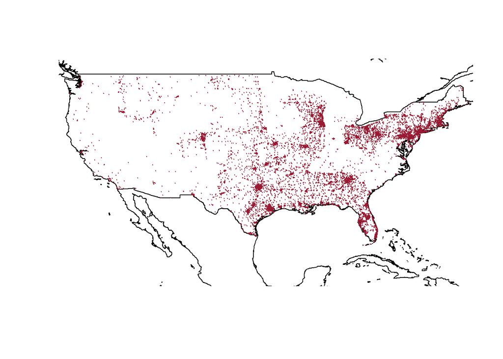

```r
map <- getMap(resolution = 'high')
plot(map, xlim = c(-120, -72), ylim = c(20, 50), asp = 1)
points(injury_data$Longitude, injury_data$Latitude, col = rgb(0.6, 0.1, 0.2), cex = 0.1)
```

I thought the map would simply look more like a population map of the states, as of most graphs of this type, but it actually seems fairly spread out through the states.

The first thing I see is the concentration of injuries on the East coast and lack thereof on the West. There is also a huge gap between the New England states and the Southern states where there is a significant decrease in injuries. My first intuition tells me that this is a result of the types of industry at each location.

I did ignore the states and territories outside the central block, so let me graph that too.

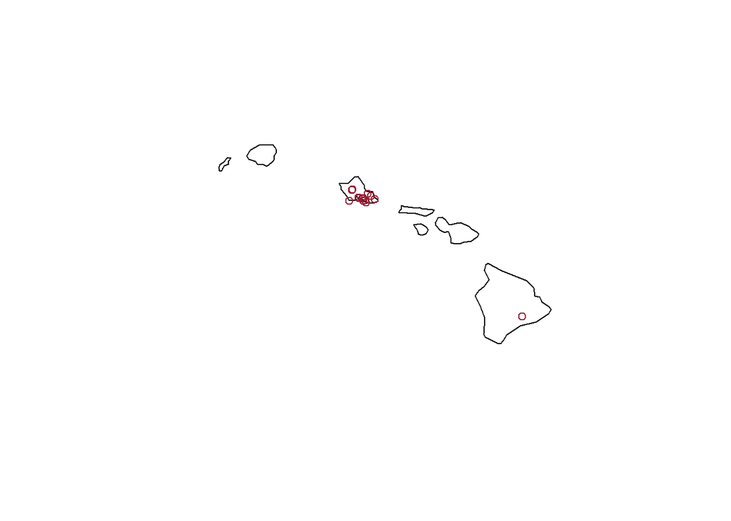

```r
map_hawaii <- getMap(resolution = 'low')
plot(map_hawaii, xlim = c(-160, -155), ylim = c(18, 23), asp = 1)
points(injury_data$Longitude, injury_data$Latitude, col = rgb(0.6, 0.1, 0.2), cex = 1)
```

```r
hawaii_plot <- recordPlot('rworldmap')
```

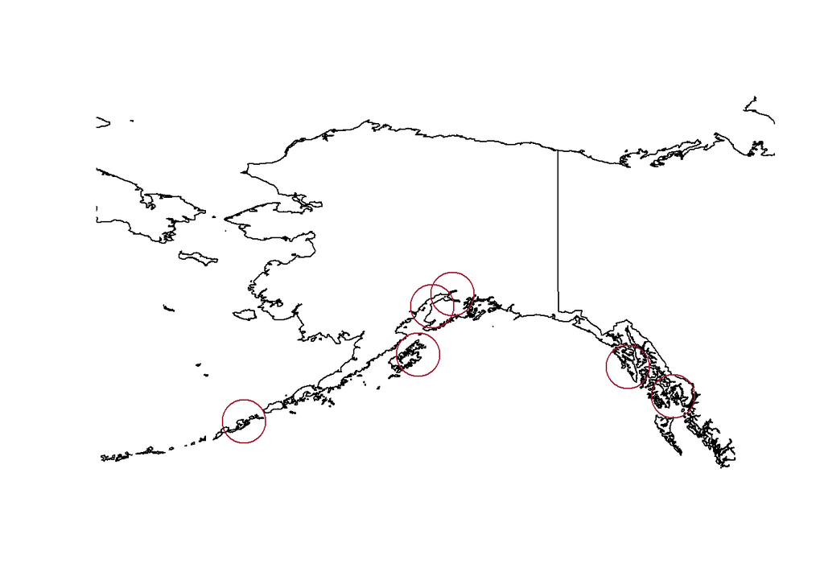

```r
map_alaska <- getMap(resolution = 'high')
alaska_plot <- plot(map_alaska, xlim = c(-172, -130), ylim = c(52, 72), asp = 1.4)
points(injury_data$Longitude, injury_data$Latitude, col = rgb(0.6, 0.1, 0.2), cex = 5)
```

I had to bloat up the dot sizes for Alaska due to the small number of injuries.

One immediate downside of the vanilla plot function that I see is that the function does not return some sort of object which could allow me to reuse it for later, but besides inconvenience it’s not a huge deal.

### Most Dangerous Locations and Companies

Next I want to see which locations have the most dangerous workplaces. From the previous map, we can assume one of the top locations will be Texas, considering its still crowded dot density over such a large land mass.

We can use the default order() function to sort our data.frame by a specific row.

```r
# Gets table with each state tied to the amount of time is shows up
injury_by_state <- table(injury_data$State)

# Sorts the table by value
injury_by_state <- injury_by_state[order(injury_by_state, decreasing = TRUE)]

# Only get first ten entities
injury_by_state_head <- head(injury_by_state, n = 10)

# Convert to data.frame
injury_by_state_head <- as.data.frame(injury_by_state_head)

colnames(injury_by_state_head) <- c('State', 'Freq')

print(injury_by_state_head)
```

```
##           State Freq
## 1         TEXAS 3481
## 2       FLORIDA 2160
## 3  PENNSYLVANIA 1723
## 4          OHIO 1658
## 5      ILLINOIS 1362
## 6       GEORGIA 1156
## 7      NEW YORK 1069
## 8     WISCONSIN  917
## 9       ALABAMA  677
## 10     MISSOURI  675
```

Turns out my guess was right. Texas seems to be one of the more dangerous states to work, followed by Florida.

Let me put this in a bar graph so it’s easier to look at.

```r
library(ggplot2)
```

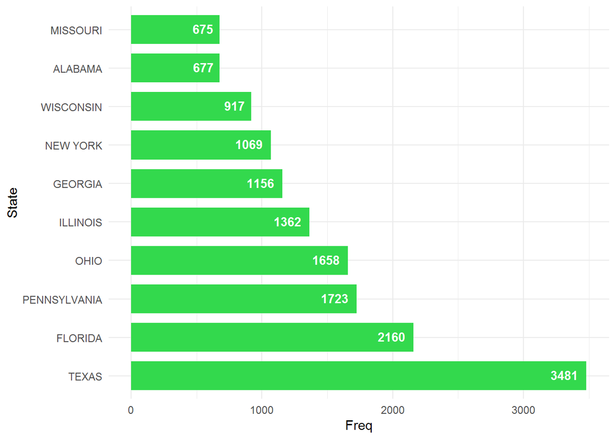

```r
state_plot <- ggplot(data = injury_by_state_head, aes(x = State, y = Freq)) +
  geom_bar(stat = 'identity', fill = rgb(0.2, 0.85, 0.3), width = 0.75) +
  theme_minimal() +
  geom_text(aes(label = Freq), size = 3.5, hjust = 1.3,
            fontface = 'bold', colour = 'white', vjust = .4) +
  coord_flip()
state_plot
```

I want to do the same for both companies and cities. First I’ll make a function to abstract the process.

```r
sortAndGraph <- function(column, name, color) {
  # Convert column to table
  injury_by_col <- table(column)

  # Sorts the table by value
  injury_by_col <- injury_by_col[order(injury_by_col, decreasing = TRUE)]

  # Only get first ten entities
  injury_by_col_head <- head(injury_by_col, n = 10)

  # Convert to data.frame
  injury_by_col_head <- as.data.frame(injury_by_col_head)

  # Name columns in data.frame
  colnames(injury_by_col_head) <- c(name, 'Freq')

  state_plot <- ggplot(data = injury_by_col_head, aes_string(x = name, y = 'Freq')) +
    geom_bar(stat = 'identity', fill = color, width = 0.75) +
    theme_minimal() +
    geom_text(aes(label = Freq), size = 3.5, hjust = 1.3,
            fontface = 'bold', colour = 'white', vjust = .4) +
    coord_flip()

  return(state_plot)
}
```

```r
city_plot <- sortAndGraph(injury_data$City, 'City', rgb(0.6, 0.5, 0.7))
employer_plot <- sortAndGraph(injury_data$Employer, 'Employer', rgb(1, 0.5, 0.7))
```

```r
library(gridExtra)
```

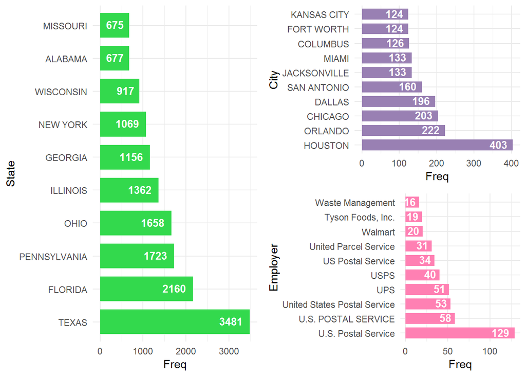

```r
layout <- rbind(c(1,2), c(1,3))
grid.arrange(state_plot, city_plot, employer_plot, ncol = 2, layout_matrix = layout)
```

Working at the US Postal Service is apparently so dangerous, it shows up 5 times in our company chart. Seems like the data isn’t perfectly cleaned though which is a bit problematic. I’m not entirely sure how to deal with this yet in an automated process, so I’ll just conclude that working in the mail delivery industry is quite dangerous.

Finally, I’ll look at the main causes of injury.

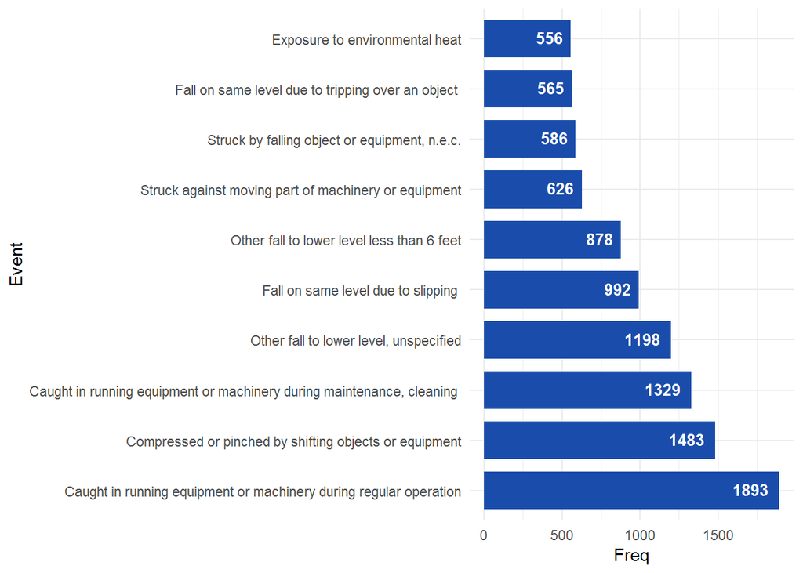

```r
sortAndGraph(injury_data$EventTitle, 'Event', rgb(0.1, 0.3, 0.67))
```

Looks painful. Seeing how being caught in running equipment is the predominant cause of injury, I can see how the mailing industry, where the mail is mainly sorted and distributed with automated machinery, can be such a dangerous industry.